# Advanced graphics with R_part 2

### ascendingly

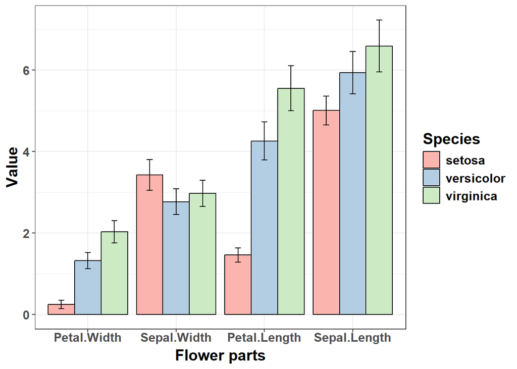

```r
ggplot(barsummary_all, aes(x=reorder(variable,mvalue), y=mvalue,fill=Species)) + geom_bar(position="dodge",color="black",stat="identity") + labs(x="Flower parts", y="Value")+geom_errorbar(aes(ymin=mvalue-sd,ymax=mvalue+sd),position=position_dodge(0.9), width=.2)+ theme_bw()+theme(text = element_text(size=15, face="bold", colour="black"),axis.text.x = element_text(vjust=2))+scale_fill_brewer(palette="Pastel1")
```

### descendingly

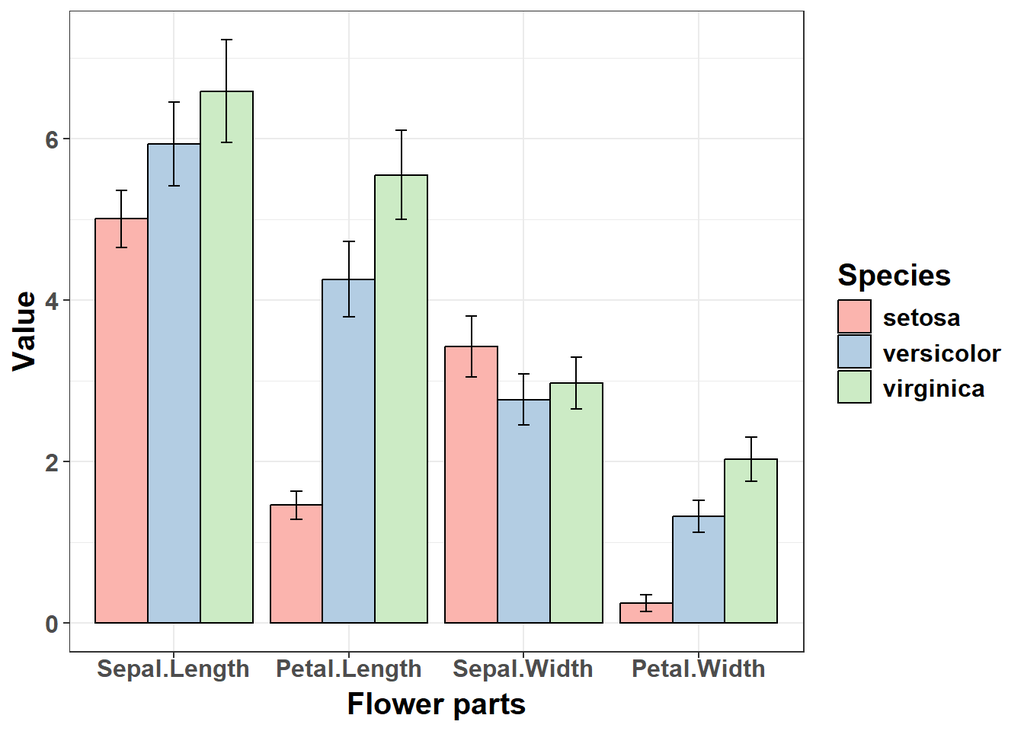

```r
ggplot(barsummary_all, aes(x=reorder(variable,-mvalue), y=mvalue,fill=Species)) + geom_bar(position="dodge",color="black",stat="identity") + labs(x="Flower parts", y="Value")+geom_errorbar(aes(ymin=mvalue-sd,ymax=mvalue+sd),position=position_dodge(0.9), width=.2)+ theme_bw()+theme(text = element_text(size=15, face="bold", colour="black"),axis.text.x = element_text(vjust=2))+scale_fill_brewer(palette="Pastel1")
```

### you can control almost anything in the graph, for example the width of the column

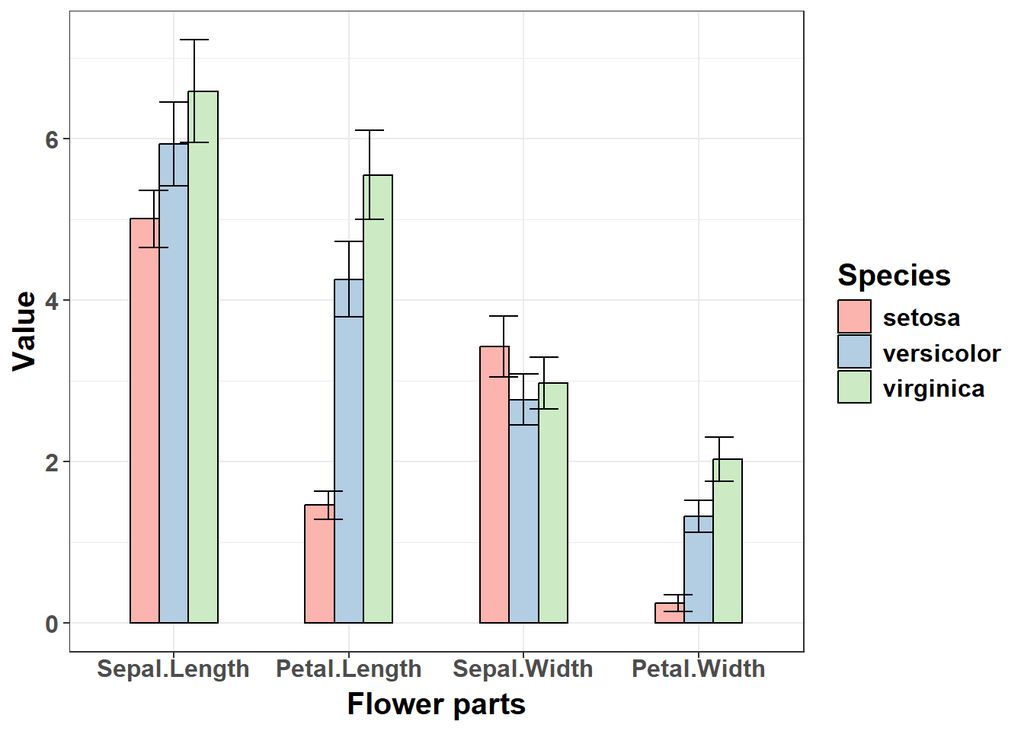

```r
ggplot(barsummary_all, aes(x=reorder(variable,-mvalue), y=mvalue,fill=Species)) + geom_bar(position="dodge",color="black",stat="identity",width=0.5) + labs(x="Flower parts", y="Value")+geom_errorbar(aes(ymin=mvalue-sd,ymax=mvalue+sd),position=position_dodge(0.35), width=.5)+ theme_bw()+theme(text = element_text(size=15, face="bold", colour="black"),axis.text.x = element_text(vjust=2))+scale_fill_brewer(palette="Pastel1")
```

### but you will need also to tweak the error bar dimensions

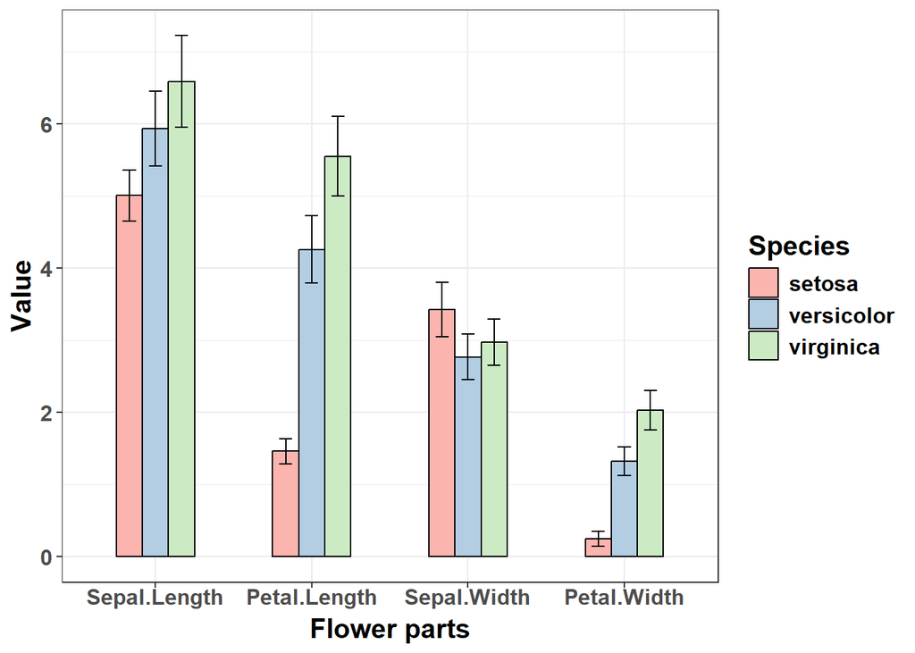

```r
ggplot(barsummary_all, aes(x=reorder(variable,-mvalue), y=mvalue,fill=Species)) + geom_bar(position="dodge",color="black",stat="identity",width=0.5) + labs(x="Flower parts", y="Value")+geom_errorbar(aes(ymin=mvalue-sd,ymax=mvalue+sd),position=position_dodge(0.5), width=.25)+ theme_bw()+theme(text = element_text(size=15, face="bold", colour="black"),axis.text.x = element_text(vjust=2))+scale_fill_brewer(palette="Pastel1")
```

## 12. Stacked bar plot

### Stacked bar plot will have the same approach as bar plot. the only difference that i will remove error bar info from the code and i will remove also position =“dodge” [this one tells R to plot side by side]. comapre between the following code and the earlier one

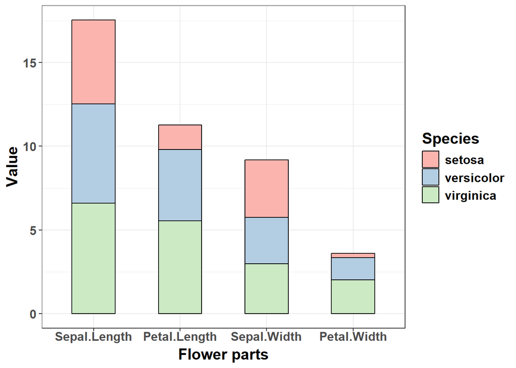

```r
ggplot(barsummary_all, aes(x=reorder(variable,-mvalue), y=mvalue,fill=Species)) + geom_bar(color="black",stat="identity",width=0.5) + labs(x="Flower parts", y="Value")+ theme_bw()+theme(text = element_text(size=15, face="bold", colour="black"),axis.text.x = element_text(vjust=2))+scale_fill_brewer(palette="Pastel1")
```

### the latest graph shows stacked bars of absolute values. In many cases for stacked bar, we need to show proportion between them. Here is what you have to do.

```r
 barsummary_all
```

```
##       Species     variable mvalue medvalue        sd  n         se
## 1      setosa Sepal.Length  5.006     5.00 0.3524897 50 0.04984957
## 2      setosa  Sepal.Width  3.428     3.40 0.3790644 50 0.05360780
## 3      setosa Petal.Length  1.462     1.50 0.1736640 50 0.02455980
## 4      setosa  Petal.Width  0.246     0.20 0.1053856 50 0.01490377
## 5  versicolor Sepal.Length  5.936     5.90 0.5161711 50 0.07299762
## 6  versicolor  Sepal.Width  2.770     2.80 0.3137983 50 0.04437778
## 7  versicolor Petal.Length  4.260     4.35 0.4699110 50 0.06645545
## 8  versicolor  Petal.Width  1.326     1.30 0.1977527 50 0.02796645
## 9   virginica Sepal.Length  6.588     6.50 0.6358796 50 0.08992695
## 10  virginica  Sepal.Width  2.974     3.00 0.3224966 50 0.04560791
## 11  virginica Petal.Length  5.552     5.55 0.5518947 50 0.07804970
## 12  virginica  Petal.Width  2.026     2.00 0.2746501 50 0.03884138
```

### devide the table into parts by grouping based on Species

```r
grouped <- group_by(barsummary_all,Species)
```

### lets see it

```r
grouped # note Group=3, means that the dataset was subsetted into 3 parts
```

```
## # A tibble: 12 × 7
## # Groups:   Species [3]
##    Species    variable     mvalue medvalue    sd     n     se
##    <fct>      <fct>         <dbl>    <dbl> <dbl> <int>  <dbl>
##  1 setosa     Sepal.Length  5.01      5    0.352    50 0.0498
##  2 setosa     Sepal.Width   3.43      3.4  0.379    50 0.0536
##  3 setosa     Petal.Length  1.46      1.5  0.174    50 0.0246
##  4 setosa     Petal.Width   0.246     0.2  0.105    50 0.0149
##  5 versicolor Sepal.Length  5.94      5.9  0.516    50 0.0730
##  6 versicolor Sepal.Width   2.77      2.8  0.314    50 0.0444
##  7 versicolor Petal.Length  4.26      4.35 0.470    50 0.0665
##  8 versicolor Petal.Width   1.33      1.3  0.198    50 0.0280
##  9 virginica  Sepal.Length  6.59      6.5  0.636    50 0.0899
## 10 virginica  Sepal.Width   2.97      3    0.322    50 0.0456
## 11 virginica  Petal.Length  5.55      5.55 0.552    50 0.0780
## 12 virginica  Petal.Width   2.03      2    0.275    50 0.0388
```

### mutate function in ddplyr adds new column to existing table by applying some operations.

```r
barsummary_all2 <- grouped %>% mutate(percentage=mvalue/sum(mvalue)*100) # telling R to generate a new data called barsummary_all2 by reading grouped data and adding a new column called percentage that fullfills the equation; mvalue devided by the sum (of each group) then *100 to get percentage.
```

### lets see what we have here

```
## # A tibble: 12 × 8
## # Groups:   Species [3]
##    Species    variable     mvalue medvalue    sd     n     se percentage
##    <fct>      <fct>         <dbl>    <dbl> <dbl> <int>  <dbl>      <dbl>
##  1 setosa     Sepal.Length  5.01      5    0.352    50 0.0498      49.4
##  2 setosa     Sepal.Width   3.43      3.4  0.379    50 0.0536      33.8
##  3 setosa     Petal.Length  1.46      1.5  0.174    50 0.0246      14.4
##  4 setosa     Petal.Width   0.246     0.2  0.105    50 0.0149       2.43
##  5 versicolor Sepal.Length  5.94      5.9  0.516    50 0.0730      41.5
##  6 versicolor Sepal.Width   2.77      2.8  0.314    50 0.0444      19.4
##  7 versicolor Petal.Length  4.26      4.35 0.470    50 0.0665      29.8
##  8 versicolor Petal.Width   1.33      1.3  0.198    50 0.0280       9.28
##  9 virginica  Sepal.Length  6.59      6.5  0.636    50 0.0899      38.4
## 10 virginica  Sepal.Width   2.97      3    0.322    50 0.0456      17.4
## 11 virginica  Petal.Length  5.55      5.55 0.552    50 0.0780      32.4
## 12 virginica  Petal.Width   2.03      2    0.275    50 0.0388      11.8
```

### now i will plot my graph. Note that i will change the dataset name to barsummary_all2 and i will change y axis to percentage

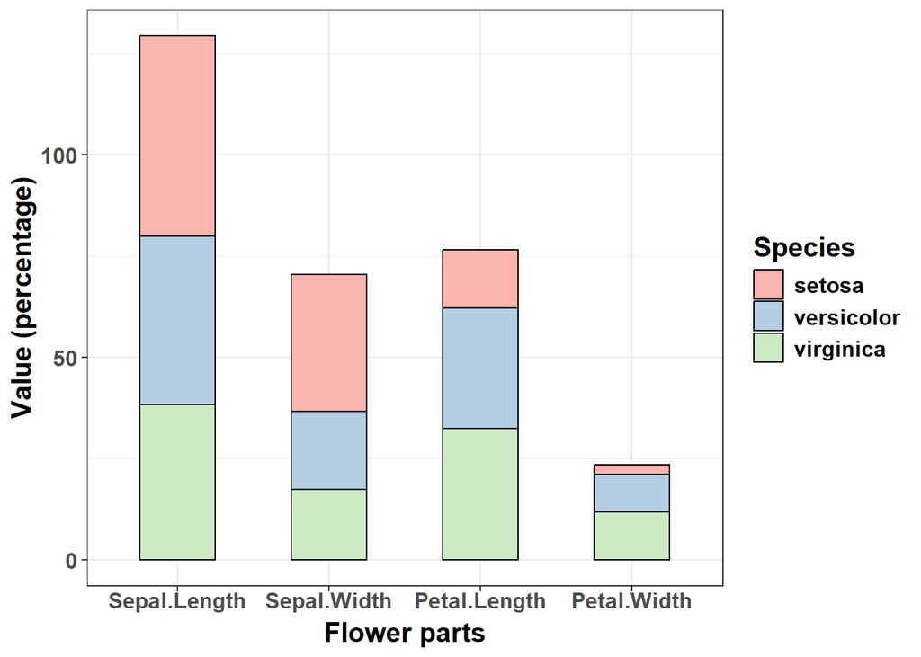

```r
ggplot(barsummary_all2, aes(x=variable, y=percentage,fill=Species)) + geom_bar(color="black",stat="identity",width=0.5) + labs(x="Flower parts", y="Value (percentage)")+ theme_bw()+theme(text = element_text(size=15, face="bold", colour="black"),axis.text.x = element_text(vjust=2))+scale_fill_brewer(palette="Pastel1")
```